### 0.0.1 To upgrade to the latest version of sparklyr, run the following command and restart your r session:

```r
install.packages("devtools")
devtools::install_github("rstudio/sparklyr")
```

### 0.0.2 You should also install a local version of Spark for development purposes:

```r
library(sparklyr)
#spark_install(version = "2.3.0")
```

# 1 Connecting to Spark

You can connect to both local instances of Spark as well as remote Spark clusters. Here we’ll connect to a local instance of Spark via the spark_connect function:

```r
library(sparklyr)
sc <- spark_connect(master = "local")
```

### 1.0.1 Using dyplyr[^1]

```r
install.packages(c("nycflights13", "Lahman"))
```

```r
library(dplyr)
```

Attaching package: ‘dplyr’

The following objects are masked from ‘package:stats’:

```
 filter, lag
```

The following objects are masked from ‘package:base’:

```
 intersect, setdiff, setequal, union
```

```r
iris_tbl <- copy_to(sc, iris)
flights_tbl <- copy_to(sc, nycflights13::flights, "flights")
batting_tbl <- copy_to(sc, Lahman::Batting, "batting")
src_tbls(sc)
```

```
## [1] "batting" "flights" "iris"
```

To start with here’s a simple filtering example:

```r
# filter by departure delay and print the first few records
flights_tbl %>% filter(dep_delay == 2)
```

```
## # Source: spark<?> [?? x 19]
##     year month   day dep_time sched_dep_time dep_delay arr_time
##    <int> <int> <int>    <int>          <int>     <dbl>    <int>
##  1  2013     1     1      517            515         2      830
##  2  2013     1     1      542            540         2      923
##  3  2013     1     1      702            700         2     1058
##  4  2013     1     1      715            713         2      911
##  5  2013     1     1      752            750         2     1025
##  6  2013     1     1      917            915         2     1206
##  7  2013     1     1      932            930         2     1219
##  8  2013     1     1     1028           1026         2     1350
##  9  2013     1     1     1042           1040         2     1325
## 10  2013     1     1     1231           1229         2     1523
## # … with more rows, and 12 more variables: sched_arr_time <int>,
## #   arr_delay <dbl>, carrier <chr>, flight <int>, tailnum <chr>,
## #   origin <chr>, dest <chr>, air_time <dbl>, distance <dbl>, hour <dbl>,
## #   minute <dbl>, time_hour <dttm>
```

Introduction to dplyr provides additional dplyr examples you can try. For example, consider the last example from the tutorial which plots data on flight delays:

```r
delay <- flights_tbl %>%
  group_by(tailnum) %>%
  summarise(count = n(), dist = mean(distance), delay = mean(arr_delay)) %>%
  filter(count > 20, dist < 2000, !is.na(delay)) %>%
  collect
```

**Warning** Missing values are always removed in SQL.

Use `AVG(x, na.rm = TRUE)` to silence this warning

Use `AVG(x, na.rm = TRUE)` to silence this warning

```r
# plot delays
library(ggplot2)
ggplot(delay, aes(dist, delay)) +
  geom_point(aes(size = count), alpha = 1/2) +
  geom_smooth() +
  scale_size_area(max_size = 2)
```

`geom_smooth()` using method = ‘gam’ and formula ‘y ~ s(x, bs = “cs”)’

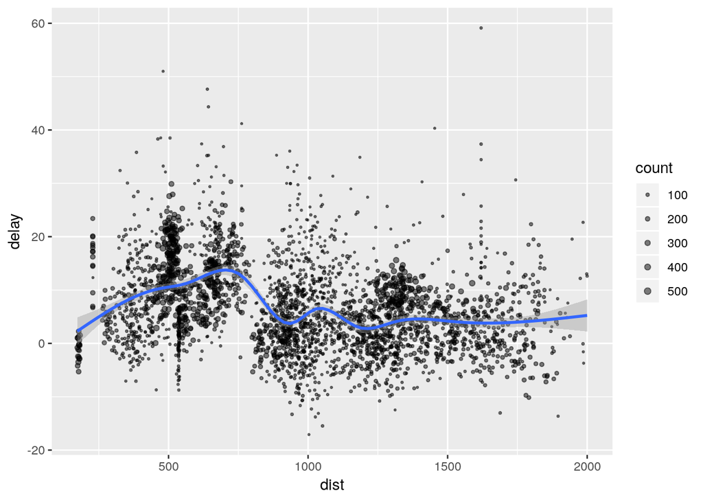

### Usinfg SQL ***

It’s also possible to execute SQL queries directly against tables within a Spark cluster. The spark_connection object implements a DBI interface for Spark, so you can use dbGetQuery to execute SQL and return the result as an R data frame:

```r
library(DBI)
iris_preview <- dbGetQuery(sc, "SELECT * FROM iris LIMIT 10")
iris_preview
```

```
##    Sepal_Length Sepal_Width Petal_Length Petal_Width Species
## 1           5.1         3.5          1.4         0.2  setosa
## 2           4.9         3.0          1.4         0.2  setosa
## 3           4.7         3.2          1.3         0.2  setosa
## 4           4.6         3.1          1.5         0.2  setosa
## 5           5.0         3.6          1.4         0.2  setosa
## 6           5.4         3.9          1.7         0.4  setosa
## 7           4.6         3.4          1.4         0.3  setosa
## 8           5.0         3.4          1.5         0.2  setosa
## 9           4.4         2.9          1.4         0.2  setosa
## 10          4.9         3.1          1.5         0.1  setosa
```

### 1.0.2 ML

```r
# copy mtcars into spark
mtcars_tbl <- copy_to(sc, mtcars)

# transform our data set, and then partition into 'training', 'test'
partitions <- mtcars_tbl %>%
  filter(hp >= 100) %>%
  mutate(cyl8 = cyl == 8) %>%
  sdf_partition(training = 0.5, test = 0.5, seed = 1099)

# fit a linear model to the training dataset
fit <- partitions$training %>%
  ml_linear_regression(response = "mpg", features = c("wt", "cyl"))
fit
```

```
## Formula: mpg ~ wt + cyl
##
## Coefficients:
## (Intercept)          wt         cyl
##   33.499452   -2.818463   -0.923187
```

Spark machine learning supports a wide array of algorithms and feature transformations and as illustrated above it’s easy to chain these functions together with dplyr pipelines. To learn more see the machine learning section.

### 1.0.3 Connection Utilities

```r
spark_web(sc)
```

```r
spark_log(sc, n = 10)
```

[output not shown]

```r
spark_disconnect(sc)
```

### 1.0.4 Using H20

rsparkling is a CRAN package from H2O that extends sparklyr to provide an interface into Sparkling Water. For instance, the following example installs, configures and runs h2o.glm:

```r
library(rsparkling)
library(sparklyr)
library(dplyr)
library(h2o)
```

Your next step is to start H2O:

```
 > h2o.init()
```

For H2O package documentation, ask for help:

```
 > ??h2o
```

After starting H2O, you can use the Web UI at http://localhost:54321

For more information visit http://docs.h2o.ai

The following objects are masked from ‘package:stats’:

```
 cor, sd, var
```

The following objects are masked from ‘package:base’:

[output not shown]

```r
sc <- spark_connect(master = "local", version = "2.3.0")
```

Spark version 2.3 detected. Will call latest Sparkling Water version 2.3.19

To update your h2o R package, copy/paste the following commands and then restart your R session:

[output not shown]

```r
mtcars_tbl <- copy_to(sc, mtcars, "mtcars",overwrite = T)

mtcars_h2o <- as_h2o_frame(sc, mtcars_tbl, strict_version_check = FALSE)

mtcars_glm <- h2o.glm(x = c("wt", "cyl"),
                      y = "mpg",
                      training_frame = mtcars_h2o,
                      lambda_search = TRUE)
mtcars_glm
```

```
## Model Details:
## ==============
##
## H2ORegressionModel: glm
## Model ID:  GLM_model_R_1547416988207_1
## GLM Model: summary
##     family     link                              regularization
## 1 gaussian identity Elastic Net (alpha = 0.5, lambda = 0.1013 )
##                                                                lambda_search
## 1 nlambda = 100, lambda.max = 10.132, lambda.min = 0.1013, lambda.1se = -1.0
##   number_of_predictors_total number_of_active_predictors
## 1                          2                           2
##   number_of_iterations                                training_frame
## 1                  100 frame_rdd_32_98c4c566c98c5dbe354facba09fa448d
##
## Coefficients: glm coefficients
##       names coefficients standardized_coefficients
## 1 Intercept    38.941654                 20.090625
## 2       cyl    -1.468783                 -2.623132
## 3        wt    -3.034558                 -2.969186
##
## H2ORegressionMetrics: glm
## ** Reported on training data. **
##
## MSE:  6.017684
## RMSE:  2.453097
## MAE:  1.940985
## RMSLE:  0.1114801
## Mean Residual Deviance :  6.017684
## R^2 :  0.8289895
## Null Deviance :1126.047
## Null D.o.F. :31
## Residual Deviance :192.5659
## Residual D.o.F. :29
## AIC :156.2425
```

```r
spark_disconnect(sc)
```

[^1]: Adopted from https://github.com/rstudio/sparklyr